# Online recognition of concert hall acoustics listening experiment

ME

Last September (2020) we published the article [“Recognizing individual concert halls is difficult when listening to the acoustics with different musical passages”](https://asa.scitation.org/doi/10.1121/10.0001915). The title already tells a lot of this experiment, where the subjects were required to recognize halls just by listening to the acoustics of the halls, but in cases where the sounds (i.e. excitation of the hall acoustics) were exactly the same, or somewhat different (see the article for more details.).

The following figures summarise the main results:

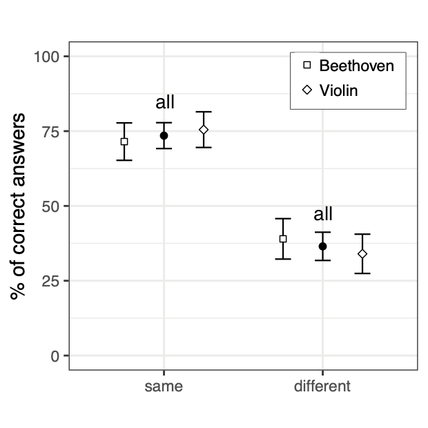

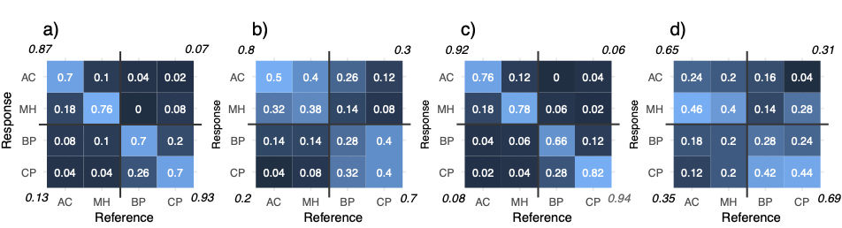

In any case, the story is that for this work I also experimented with [RShiny](https://shiny.rstudio.com/) to see if it can be used for making online listening experiments. Originally the idea was only to facilitate the review process, so that, the reviewers could go and have a listen for themselves. Here is link to this [online test](https://anttikuusinen.shinyapps.io/RoomAcousticsMatchingExperiment/).

However, we were also fortunate to publish another article shortly after: [Perception of loudness and envelopment for different orchestral dynamics](https://asa.scitation.org/doi/full/10.1121/10.0002101). All together these two studies gained some momentum and was noted with [a press release](https://www.aalto.fi/en/news/can-you-identify-which-concert-hall-this-music-is-being-played-in-test-to-see) to be spread out more widely.

Unfortunately, only in the aftermath I did realize that the online test is overly long for most people to finish in realistic time, and I suspect that there have been quite a lot of people who have started the test but not completed. Nevertheless, I happy to note that there are now 40 people who have taken the time and completed the online test. I will shortly look at the results here. (Note, that analyzing this type if data in R was already discussed in the [previous post](https://anttikuusinen.github.io/post/2020-22-01-chm/2020-22-01-chm/), so here, I will just cover the main results of the online listening experiment.

So, here are the results in the similar figures as above:

Basically these results follow those presented in the article, but they are much worse. As mentioned, the test was relatively long, so I suspect that these results are affected by the length of the experiment.

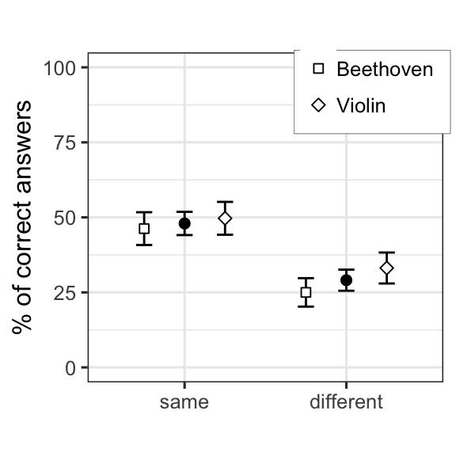

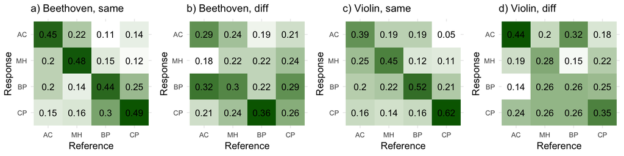

```
##
##  Exact binomial test
##
## data:  same_corn and same_totn
## number of successes = 307, number of trials = 640, p-value <
## 2.2e-16
## alternative hypothesis: true probability of success is greater than 0.25
## 95 percent confidence interval:
##  0.4465431 1.0000000
## sample estimates:
## probability of success
##              0.4796875
```

```
##
##  Exact binomial test
##
## data:  diff_corn and diff_totn
## number of successes = 186, number of trials = 640, p-value =
## 0.01081
## alternative hypothesis: true probability of success is greater than 0.25
## 95 percent confidence interval:
##  0.2610833 1.0000000
## sample estimates:
## probability of success
##               0.290625
```

Binomial test results.

## Link to the [new experiment](https://anttikuusinen.shinyapps.io/MatchingTest2/).

Leave a comment: